# Part 1 - Distribution of Age, Sex, Birthday and ZipCode

# Analysis

First, we learned from these resources that only knowing personal information on zip-code, gender, age, or birthday is hardly sufficient to successfully identify any individual. That said, there is a reasonable chance of identifying certain groups of individuals by knowing zip-code. Second, if an individual’s records on all four variables were available, identifying a small group of individuals or uniquely identifying one individual becomes possible with reasonable certainty.

So is it possible to directly identify an individual with a combination of the above pieces of information? Before digging into our response to this question, it is worth noting that since we were unable to find large and diverse datasets in which an individual’s information on zip code, gender, age, and birthday are recorded all at once or could be recognized by joining different datasets, we performed a hypothetical analysis based on the resources we did find. With that in mind, we argue that identification with reasonable certainty is very likely to be realized, assuming we have knowledge of all four basic demographic variables. However, identification is not a certainty and depends on the number of people residing in a zip code, as well as the age and birthday distributions in said ZIP population.

For example, if a zip code has a small population like the one illustrated above with 17 residents, we could easily identify a specific individual by their gender and age if the distribution of age is unimodal (like the dataset we found), especially if they are an outlier. However, even if the population is relatively homogenous such that most of the residents are between the ages of 40-49 yrs, this would not pose a significant challenge given our dataset, as the variable is as precise as a single year difference. More directly, we could easily identify a specific individual by their birthday, given the low probability of two persons being born on the same date in a small population. However, to examine an opposing example, if a zip code has a large population (e.g., 01075; a community with 14590 residents in Hampshire County, MA), the percentage of its population considered identifiable will decrease considerably when compared to those zip codes with much smaller populations. This is because the number of people under consideration for each gender and age subgroup becomes larger and the zip population passes the threshold of minimum people required to guarantee at least two of them were born on exactly the same date. This being said, there still remains the possibility of identifying individuals uniquely if they are outliers in the age distribution and could, therefore, be identified by their much more unique birth date.

# Part 2 - EdX

```python
data = pd.read_csv('APCOMP221Pset1.csv', low_memory=False)
```

> Here, we use low_memory=False to solve the possible data reading problems with pandas package. To confirm that we avoid the problem, I double check with the method using iteration without package.

```python
num_rows = 0

for row in open("APCOMP221Pset1.csv"):
    num_rows += 1

print(num_rows)
print(data.shape[0] + 1)
```

```
1141736
1141736
```

```python
data.head()
```

|  | course_id | user_id | username | registered | viewed | explored | certified | completed | ip | cc_by_ip | ... | roles_isInstructor | roles_isStaff | roles_isCCX | roles_isFinance | roles_isLibrary | roles_isSales | forumRoles_isAdmin | forumRoles_isCommunityTA | forumRoles_isModerator | forumRoles_isStudent |
| --- | --- | --- | --- | --- | --- | --- | --- | --- | --- | --- | --- | --- | --- | --- | --- | --- | --- | --- | --- | --- | --- |
| 0 | HarvardX/PH525.1x/1T2018 | 1488411 | KIRSTEN SUAREZ | True | False | NaN | False | False | 81.108.107.58 | GB | ... | NaN | NaN | NaN | NaN | NaN | NaN | NaN | NaN | NaN | 1.0 |
| 1 | HarvardX/PH525.1x/1T2018 | 7013084 | CAREY FOSTER | True | True | True | False | False | 205.175.107.76 | US | ... | NaN | NaN | NaN | NaN | NaN | NaN | NaN | NaN | NaN | 1.0 |
| 2 | HarvardX/PH525.1x/1T2018 | 4083257 | CLAUDINE FARMER | True | True | False | False | False | 103.212.146.137 | NaN | ... | NaN | NaN | NaN | NaN | NaN | NaN | NaN | NaN | NaN | 1.0 |
| 3 | HarvardX/PH525.1x/1T2018 | 4605571 | SHEREE BONNER | True | True | False | False | False | 172.221.204.94 | US | ... | NaN | NaN | NaN | NaN | NaN | NaN | NaN | NaN | NaN | 1.0 |
| 4 | HarvardX/PH525.1x/1T2018 | 1499820 | MITCHELL VALDEZ | True | True | True | False | False | 193.225.200.92 | HU | ... | NaN | NaN | NaN | NaN | NaN | NaN | NaN | NaN | NaN | 1.0 |

5 rows × 92 columns

```python
data.describe()
```

|  | user_id | latitude | longitude | YoB | grade | passing_grade | nevents | ndays_act | nplay_video | nchapters | ... | roles_isInstructor | roles_isStaff | roles_isCCX | roles_isFinance | roles_isLibrary | roles_isSales | forumRoles_isAdmin | forumRoles_isCommunityTA | forumRoles_isModerator | forumRoles_isStudent |
| --- | --- | --- | --- | --- | --- | --- | --- | --- | --- | --- | --- | --- | --- | --- | --- | --- | --- | --- | --- | --- | --- |
| count | 1.141735e+06 | 959097.000000 | 959097.000000 | 967016.000000 | 820668.000000 | 1.122638e+06 | 874250.000000 | 874420.000000 | 874250.000000 | 584037.000000 | ... | 491.0 | 601.0 | 0.0 | 1.0 | 0.0 | 6.0 | 129.0 | 0.0 | 143.0 | 1141689.0 |
| mean | 5.009897e+06 | 29.103567 | -11.946091 | 1984.313397 | 0.040440 | 6.512879e-01 | 310.239641 | 6.768124 | 41.016666 | 3.018535 | ... | 1.0 | 1.0 | NaN | 1.0 | NaN | 1.0 | 1.0 | NaN | 1.0 | 1.0 |
| std | 2.886072e+06 | 22.482710 | 79.205522 | 12.380391 | 0.165155 | 8.379113e-02 | 2051.392290 | 21.330110 | 393.593691 | 3.590362 | ... | 0.0 | 0.0 | NaN | NaN | NaN | 0.0 | 0.0 | NaN | 0.0 | 0.0 |
| min | 4.000000e+00 | -90.000000 | -175.201800 | 1893.000000 | 0.000000 | 5.000000e-01 | 1.000000 | 1.000000 | 0.000000 | 1.000000 | ... | 1.0 | 1.0 | NaN | 1.0 | NaN | 1.0 | 1.0 | NaN | 1.0 | 1.0 |
| 25% | 2.511628e+06 | 20.000000 | -79.790900 | 1979.000000 | 0.000000 | 6.000000e-01 | 3.000000 | 1.000000 | 0.000000 | 1.000000 | ... | 1.0 | 1.0 | NaN | 1.0 | NaN | 1.0 | 1.0 | NaN | 1.0 | 1.0 |
| 50% | 5.015690e+06 | 37.417800 | -2.500000 | 1988.000000 | 0.000000 | 6.000000e-01 | 21.000000 | 2.000000 | 0.000000 | 2.000000 | ... | 1.0 | 1.0 | NaN | 1.0 | NaN | 1.0 | 1.0 | NaN | 1.0 | 1.0 |
| 75% | 7.509526e+06 | 42.833300 | 44.339400 | 1993.000000 | 0.000000 | 7.000000e-01 | 135.000000 | 5.000000 | 10.000000 | 3.000000 | ... | 1.0 | 1.0 | NaN | 1.0 | NaN | 1.0 | 1.0 | NaN | 1.0 | 1.0 |
| max | 1.000000e+07 | 72.000000 | 178.433300 | 3116.000000 | 1.190000 | 9.700000e-01 | 637584.000000 | 2648.000000 | 114562.000000 | 41.000000 | ... | 1.0 | 1.0 | NaN | 1.0 | NaN | 1.0 | 1.0 | NaN | 1.0 | 1.0 |

8 rows × 50 columns

```python
data.info()
```

```
<class 'pandas.core.frame.DataFrame'>
RangeIndex: 1141735 entries, 0 to 1141734
Data columns (total 92 columns):
 #   Column                      Non-Null Count    Dtype
---  ------                      --------------    -----
 0   course_id                   1141735 non-null  object
 1   user_id                     1141735 non-null  int64
 2   username                    1141735 non-null  object
 3   registered                  1141735 non-null  bool
 4   viewed                      1141735 non-null  bool
 5   explored                    584037 non-null   object
 6   certified                   1141735 non-null  bool
 7   completed                   1141735 non-null  bool
 8   ip                          977360 non-null   object
 9   cc_by_ip                    957309 non-null   object
```

[output cut: 84 more lines]

> After getting a general idea of different data types, we divide our variables into four groups, int64, object, bool and float64.

## Data Type of Int64

> There is 1 variable with the data type of int64.

> 1 - user_id: it's a direct identifier. Because it includes information that relates specifically to an individual. This can identify an individual on its own.

## Data Type of Object

> There are 38 variables with the data type of object. We mainly combine data description and the function check_unilink we write to check whether it's a direct identifiers or quasi-identifiers.

> check_unilink function groups the data by the values of var1 and further check whether the values of var2 is distinct in each group of var1. Since NULL might have different meanings in different variables, we ignore NULL values here. When we get the result that var1 is uniquely linked with var2, we would further check the variable to see whether NULL has influence on the classification of the variable.

```python
# check whether var1 is uniquely linked with var2
def check_unilink(data, var1, val2):
    data_group = data.groupby(by = [var1])
    for name, group in data_group:
        if len(set(list(group[val2].values))) != 1 and not group[val2].isnull().values.any():
            print(name)
            print(group.loc[:, [val2]])
            return var1 + " is not uniquely linked with " + val2
    return var1 + " is uniquely linked with " + val2
```

```python
for i in range(len(data.columns)):
    if data[data.columns[i]].dtype == np.object:
        print(check_unilink(data, data.columns[i], "user_id"))
        print("===============================================")
```

```
HarvardX/1368.1x/2T2016
        user_id
819225   547212
819226  8777510
819227  2446867
819228  5272378
819229  8922039
...         ...
820476  7989746
820477  7083197
820478  1314371
820479   253287
820480  4460182

[1256 rows x 1 columns]
course_id is not uniquely linked with user_id
===============================================
AARON ACOSTA
        user_id
102151  1798101
185037  1534477
username is not uniquely linked with user_id
===============================================
False
         user_id
2        4083257
3        4605571
5        3872821
11       8749677
13        435231
...          ...
1141560  5255744
1141594  2739923
1141616  5131865
1141678  1655170
1141722  1983808

[461779 rows x 1 columns]
explored is not uniquely linked with user_id
===============================================
```

[output cut: 455 more lines]

```
341124  8042289
341143  2366809
341158   361161
341447  2496323
341536  4062190
...         ...
416527  5508424
416581  9396069
416846  7943929
416848  1289811
417155  9523296

[1205 rows x 1 columns]
language is not uniquely linked with user_id
===============================================
```

```python
# special case
special_var = "un_developing_nation"
print("the number of distinct values for " + special_var + " is " + str(len(set(list(data[special_var].values)))))
```

```
the number of distinct values for un_developing_nation is 2
```

> 0 - course_id: course_id refers to course ID in the standard format as org/number/semester. Through the check_unilink function, we found that course_id is not uniquely linked with user_id, meaning that one certain course can be taken by multiple users in the edX system. That said, couse_id can be used as an identifier to narrow the whole range of users to certain ones that have taken this course, and by combining this variable with other variables such as age, gender, region, and etc., as well as by examining the combination of different courses, there is a reasonable chance of identifying a specific person in the system. We can thus conclude that course_id is not a direct identifier but a quasi-identifier and it is a categorical variable.

> 5 - explored: explored indicates whether the user viewed at least half of the chapters of the course (True) or not (False). Through the check_unilink function, we found that explored is not uniquely linked with user_id, meaning that multiple users viewed or didn’t view at least half of a course’s chapter. That said, explored can be used as an identifier to divide the whole range of users into two groups: those that have viewed and not viewed, and by combining this variable with other variables such as courses being taken, identification would be possible with reasonable certainty. We can thus conclude that explored is not a direct identifier but a quasi-identifier and it is a categorical variable.

> 9 - cc_by_ip refers to two-letter country code corresponding to the modal IP. Through the check_unilink function, we found that cc_by_ip is not uniquely linked with user_id, meaning that such information (e.g., AD) can be linked to multiple users. That said, cc_by_ip can be used as an identifier to divide the whole range of users into subgroups of people who are located in different countries, and by combining this variable with other demographic variables such as zip code, there is a reasonable chance of identifying a specific user. We can thus conclude that cc_by_ip is not a direct identifier but a quasi-identifier and it is a categorical variable.

> 10 - countryLabel refers to the full name of country corresponding to the modal IP. Through the check_unilink function, we found that countryLabel is not uniquely linked with user_id, meaning that such information (e.g., Afghanistan) can be linked to multiple users. The reason to conclude countryLabel as a quasi-identifier but not a direct identifier is the same as that for the above variable. countryLabel is a categorical variable. continent refers to the continent corresponding to the modal IP. Through the check_unilink function, we found that continent is not uniquely linked with user_id, meaning that such information (e.g., Africa) can be linked to multiple users. The reason to conclude continent as a quasi-identifier but not a direct identifier is the same as that for the above variable. continent is a categorical variable.

> 12 - city refers to the full name of city corresponding to the modal IP. Through the check_unilink function, we found that city is not uniquely linked with user_id, meaning that such information (e.g., s-gravenzande) can be linked to multiple users. The reason to conclude city as a quasi-identifier but not a direct identifier is the same as that for the above variable. city is a categorical variable.

> 13 - region refers to two-letter code of region or U.S. State corresponding to the modal IP. Through the check_unilink function, we found that region is not uniquely linked with user_id, meaning that such information (e.g., 00) can be linked to multiple users. The reason to conclude region as a quasi-identifier but not a direct identifier is the same as that for the above variable. region is a categorical variable.

> 14 - subdivision refers to full name of region/subdivision or U.S. State corresponding to the modal IP. Through the check_unilink function, we found that region is not uniquely linked with user_id, meaning that such information (e.g., A Coruna) can be linked to multiple users. The reason to conclude subdivision as a quasi-identifier but not a direct identifier is the same as that for the above variable. subdivision is a categorical variable.

> 15 - postalCode refers to postal code corresponding to the modal IP. Through the check_unilink function, we found that postalCode is not uniquely linked with user_id, meaning that such information (e.g., 00012) can be linked to multiple users. That said, postalCode can be used as an identifier to narrow the whole range of users down to the ones that are located in the area with a particular postal code, and by combining this variable with other variables such as age, gender, country and course being taken, there is a reasonable chance of identifying a specific user. We can thus conclude that postalCode is not a direct identifier but a quasi-identifier and it is a categorical variable.

> 16 - un_major_region refers to UN-defined subcontinent major geographic regions corresponding to the modal IP. Through the check_unilink function, we found that un_major_region is not uniquely linked with user_id, meaning that such information (e.g., Australia and New Zealand) can be linked to multiple users. That said, un*major* region can be used as an identifier to divide the whole range of users into those residing in a specific UN country, and by combining this variable with other demographic variables such as zip code, identification would be possible with reasonable certainty. We can thus conclude that un_major_region is not a direct identifier but a quasi-identifier and it is a categorical variable.

> 17 - un_economic_group refers to UN-defined developing nation groups files corresponding to the modal IP. Through the check_unilink function, we found that un_economic_group is not uniquely linked with user_id, meaning that such information (e.g., Developed regions) can be linked to multiple users. The reason to conclude un_eocnomic_group as a quasi-identifier but not a direct identifier is similar to that for the above variable, except that rather than narrowing all users down to the ones living in a specific UN country, this variable allows such narrowing process down to the ones living in either developing regions or developed regions. un_economic_group is a categorical variable.

> 18 - un_developing_nation refers to UN-defined developing nation groups files corresponding to modal IP address. It is hard to tell from the description of this variabile to determine if it is a quasi-identifier or not an identifier at all. Our analysis shows that the values of this variable are either UN or NaN but from the description we were unable to determine if NaN is missing value or has a substantial meaning. If the prior is the case, this variable would be unimodal and not an identifier at all since all users were supposed to be categorized as UN. On the other hand, if the latter is the case, this variable can be a quasi-variable as it helps narrow the whole group of users down to individuals belonging to a particular group.

> 19 - un_special_region refers to if the modal IP address corresponds to Latin America and the Caribbean or Sub-Saharan-Africa. Through the check_unilink function, we found that un_special_region is not uniquely linked with user_id, meaning that such information (e.g., Latin America and the Caribbean) can be linked to multiple users. The reason to conclude un_special_region as a quasi-identifier but not a direct identifier is similar to that for un_economic_group, except that rather than narrowing all users down to the ones living in either developing regions or developed regions, this variable allows such narrowing process down to the ones living in either Latin America or Sub-Saharan-Africa. un_special_region is a categorical variable.

> 22 - LoE refers to the level of education specified when registering for an edX account. Through the check_unilink function, we found that LoE is not uniquely linked with user_id, meaning that such information (e.g., a - associated degree) can be linked to multiple users. That said, LoE can be used as an identifier to divide the whole range of users into those with a particular education background, and by combining this variable with other demographic variables such as zip code and gender, there is a reasonable chance to identify a specific user. We can thus conclude that LoE is not a direct identifier but a quasi-identifier and it is a categorical variable.

> 24 - gender refers to the level of education specified when registering for an edX account. Through the check_unilink function, we found that gender is not uniquely linked with user_id, meaning that such information (e.g.,f - female) can be linked to multiple users. That said, gender can be used as an identifier to divide the whole range of users into those that fall into a particular gender category, and by combining this variable with other demographic variables such as zip code and education background, there is a reasonable chance to identify a specific user. We can thus conclude that gender is not a direct identifier but a quasi-identifier and it is a categorical variable.

> 27 - start_time refers to the date of enrollment in the course. Through the check_unilink function, we found that start_time is not uniquely linked with user_id, meaning that multiple users start a course on the same day. That said, start_time can be used as an identifier to narrow the whole range of users down to those starting on the same date, and by combining this variable with other variables such as zip code and gender, there is a reasonable chance to identify a specific user. We can thus conclude that start_time is not a direct identifier but a quasi-identifier and it is a categorical variable.

> 28 - first_event refers to the timestamp of user’s first event in the course from tracking logs. Through the check_unilink function, we found that first_event is not uniquely linked with user_id, meaning that such log information can be linked to multiple users. The reason to conclude first-event as a quasi-identifier but not a direct identifier is similar to that for the above variable, with the exception that this variable allows narrowing the whole range of users down to those starting the first event at the same time. first_event is a categorical variable.

> 29 - The same logic applies to the variable last_event, which refers to the timestamp of user’s last event in the course from tracking logs, with the exception that this variable allows narrowing the whole range of users down to those starting the last event at the same time. last_event is a categorical variable.

> 40 - roles refers to the roles played by the user in the course (“student” or “stuff”). Through the check_unilink function, we found that roles is not uniquely linked with user_id, meaning that such information can be linked to multiple users. That said, roles can be used as an identifier to narrow the whole range of users down to those categorized as students or stuff, and by combining this variable with other variables such as zip code and gender, there is a reasonable chance to identify a specific user. We can thus conclude that roles is not a direct identifier but a quasi-identifier and it is a categorical variable.

> 44 - The same logic applies to the variable mode, which refers to the mode of registrant (e.g., honor, audit, verified), with the exception that this variable allows narrowing the whole range of users down to those categorized as honor, audit, or verified. mode is a categorical variable.

> 46 - cert_created_date refers to the date when certificate was generated (if applicable). Through the check_unilink function, we found that cert_created_date is not uniquely linked with user_id, meaning that multiple users receive their certificates on the same day (if applicable). That said, start_time can be used as an identifier to narrow the whole range of users down to not only those who received certificates but those receiving them on the same day, and by combining this variable with other variables such as zip code and gender, there is a reasonable chance to identify a specific user. We can thus conclude that cert_created_date is not a direct identifier but a quasi-identifier and it is a categorical variable.

> 47 - The same logic applies to the variable cert_modified_date, which refers to the date when certificate was modified (if applicable), with the exception that this variable allows narrowing the whole range of users down to not only those who have modified their certificates but doing so on the same day. cert_modified_date is a categorical variable.

> 48 - cert_status refers to the status of a certificate, specified as “downloadable”, “notpassing”, “unavailable”, “audit_notpassing”, “audit_passing”, or “error”. Through the check_unilink function, we found that cert_status is not uniquely linked with user_id, meaning that multiple users hold the same certification status. That said, cert_status can be used as an identifier to narrow the whole range of users down those belonging to a specific status group, and by combining this variable with other variables such as zip code and gender, there is a reasonable chance to identify a specific user. We can thus conclude that cert_status is not a direct identifier but a quasi-identifier and it is a categorical variable.

> 49 - verified_enroll_time, referring to the time when a user initially had their first id-verified enrollment event. An inspection of the output of the check_unilink function reveals that verified_enroll_time is uniquely linked with user_id. This suggests that one single value of the variable is directly linked to a specific user_id. We thus conclude that verified_enroll_time is a direct identifier at least by the time the data is collected. There remains the possibility that as time moves on and the number of users increases, one timestamp would be linked to multiple users. By then, this variable would be a quasi-identifier, as in combination with other variables such as zip code and gender, identification would be possible with reasonable certainty.

> 50 - verified_unenroll_time, referring to the time when a user initially had their last id-verified un-enrollment event, if applicable, and NULL is never enrolled. Through the check_unilink function, we found that verified_unenroll_time uniquely linked with user_id. This suggests that one single value of the variable is directly linked to a specific user_id. However, according to the description, there is a considerable number of users who have never unenrolled in the course and are coded as NULL. With this in mind, verified_unenroll_time can be used to directly identify a user only when it has a valid value. Otherwise, it should be treated as a quasi-identifier, as it helps narrow the whole range of users down to those that do not have applicable data for verified_unenroll_time. And by combining this information with other variables, identification would be possible with reasonable certainty.

> 51 - profile_country refers to two-letter country code as specified by a user in their profile (only available after ~mid-2014). Through the check_unilink function, we found that profile_country is not uniquely linked with user_id, meaning that such information (e.g., AD) can be linked to multiple users. That said, profile_country can be used as an identifier to divide the whole range of users into subgroups of people who not only joined the edX system after ~mid-2014 and but are located in different countries, and by combining this variable with other demographic variables such as zip code and gender, there is a reasonable chance of identifying a specific user. We can thus conclude that profile_country is not a direct identifier but a quasi-identifier and it is a categorical variable.

> 53 - The same logic applies to the variable email_domain, which refers to the domain of the email address of the user, with the exception that this variable allows narrowing the whole range of users down to those with the same email domain. email_domain is a categorical variable.

> 54 - language_brwsr is found in the dataset but not not found in the student course description file. It is a mismatch between the dataset and the student course description file, which was expected because the description file is for earlier versions of what the edX platform captured about its learners and the information have changed slightly since then.

> 55 - language_brwsr_country is found in the dataset but not not found in the student course description file. It is a mismatch between the dataset and the student course description file, which was expected because the description file is for earlier versions of what the edX platform captured about its learners and the information have changed slightly since then.

> 56 - language_brwsr_sec_country is found in the dataset but not not found in the student course description file. It is a mismatch between the dataset and the student course description file, which was expected because the description file is for earlier versions of what the edX platform captured about its learners and the information have changed slightly since then.

> 58 - language_brwsr_code is found in the dataset but not not found in the student course description file. It is a mismatch between the dataset and the student course description file, which was expected because the description file is for earlier versions of what the edX platform captured about its learners and the information have changed slightly since then.

> 59 - language_brwsr_subcode is found in the dataset but not not found in the student course description file. It is a mismatch between the dataset and the student course description file, which was expected because the description file is for earlier versions of what the edX platform captured about its learners and the information have changed slightly since then.

> 60 - language_brwsr_sec_code is found in the dataset but not not found in the student course description file. It is a mismatch between the dataset and the student course description file, which was expected because the description file is for earlier versions of what the edX platform captured about its learners and the information have changed slightly since then.

> 61 - language_brwsr_sec_subcode is found in the dataset but not not found in the student course description file. It is a mismatch between the dataset and the student course description file, which was expected because the description file is for earlier versions of what the edX platform captured about its learners and the information have changed slightly since then.

> 64 - language refers to the modal transcript language. Through the check_unilink function, we found that language is not uniquely linked with user_id, meaning that such information (e.g., bn) can be linked to multiple users. That said, language can be used as an identifier to narrow the whole range of users down to those with a certain transcript language, and by combining this variable with other demographic variables such as zip code and gender, there is a reasonable chance of identifying a specific user. We can thus conclude that language is not a direct identifier but a quasi-identifier and it is a categorical variable.

## Data Type of Bool

```python
for i in range(len(data.columns)):
    if data[data.columns[i]].dtype == np.bool:
        print(data.columns[i])
        print(len(set(list(data[data.columns[i]].values))))
```

```
registered
1
viewed
2
certified
2
completed
2
```

```python
print(False in data["registered"].values)
```

```
False
```

> 3 - registered: indicating that the user registered in the course. Here, in our dataset, the variable registered cannot be catagorized into neither direct identifiers or quasi-identifiers, because they basically don't give any information for identification. The variable only has one value - True.

> 4 - viewed: indicating that the user visited the course at least once. This is a quasi-identifiers. Because it has the values of both True and False. It helps us in identification. The variable is a piece of information that does not itself identify an individual, but can do so when combined with other quasi-identifiers. It is a categorical variable.

> 7 - completed: indicated that the user completed the course by achieving a final grade above the overall passing threshold for the course (grade >= passing_grade). This is a quasi-identifiers. Because it has the values of both True and False. It helps us in identification. The variable is a piece of information that does not itself identify an individual, but can do so when combined with other quasi-identifiers. It is a categorical variable.

## Data Type of Float64

> There are 49 variables with the data type of float64.

> First, we noticed from data information, there are three variables "roles_isCCX", "roles_isLibrary", "forumRoles_isCommunityTA" which have 0 non-null values. And NULL indicates missing data from both edX roles tables. Here, in our dataset, the three variables cannot be catagorized into neither direct identifiers or quasi-identifiers, because they basically don't give any information for identification.

> Then we plot the remaining 46 variables to see their distributions. We first plot their histograms to have a general idea of whether they are continuous or categorical. For those evident continuous variables, we would use scatter plot to see whether their distributions are the same in different user_id. For those hard to identify whether it's continuous or categorical, we would get their descriptive statistics to further analyze.

```python
float_col = []
float_col_nan = ["roles_isCCX", "roles_isLibrary", "forumRoles_isCommunityTA"]
for i in range(len(data.columns)):
    if data[data.columns[i]].dtype == np.float64 and data.columns[i] not in float_col_nan:
        float_col.append(data.columns[i])
```

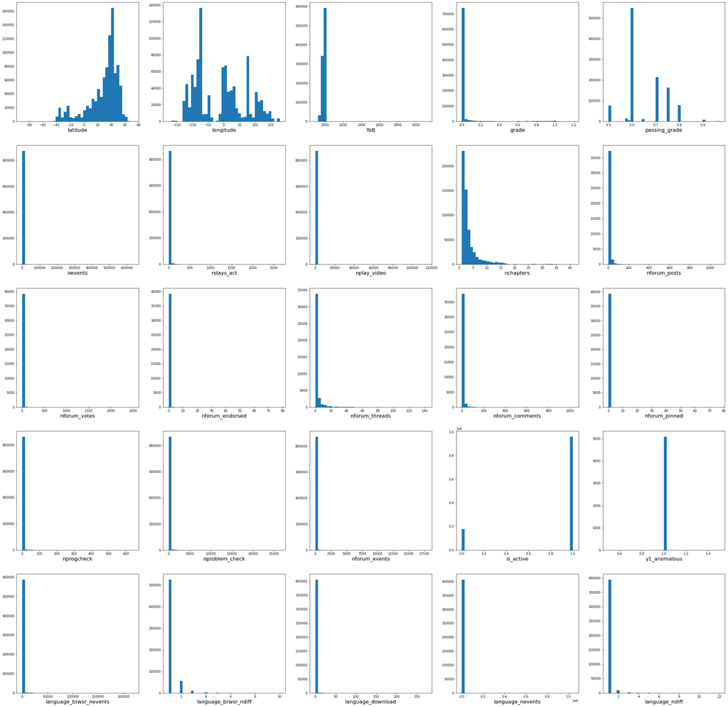

```python
fig, axes = plt.subplots(5, 5, sharey=False, figsize=(40, 40))
for i, ax in enumerate(axes.flat):
    ax.hist(data[float_col[i]], bins=40)
    ax.set_xlabel(float_col[i], fontsize=16)
```

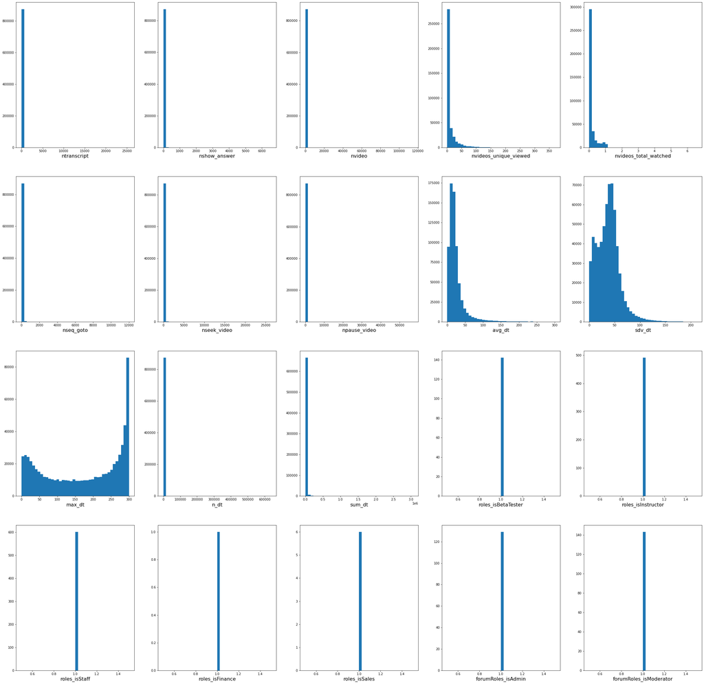

```python
fig, axes = plt.subplots(4, 5, sharey=False, figsize=(40, 40))
for i, ax in enumerate(axes.flat):
    ax.hist(data[float_col[i + 25]], bins=40)
    ax.set_xlabel(float_col[i + 25], fontsize=16)
```

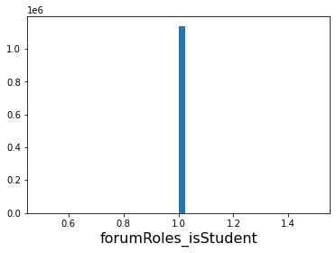

```python
plt.hist(data[float_col[45]], bins=40)
plt.xlabel(float_col[45], fontsize=16)
```

[output not shown]

[output cut: 12 more lines]

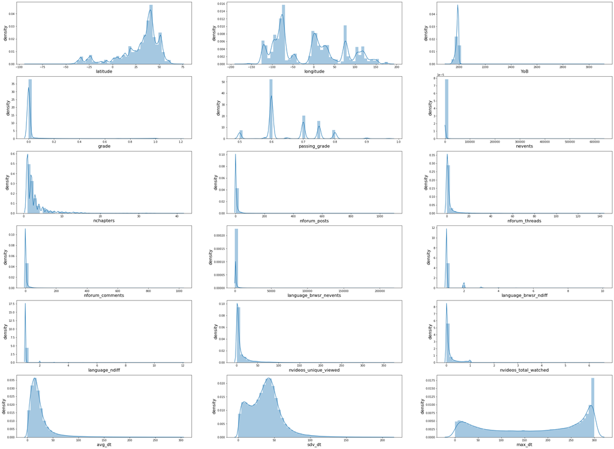

```python
selected_var = ['latitude', 'longitude', 'YoB', 'grade', 'passing_grade', 'nevents', 'nchapters',
                'nforum_posts', 'nforum_threads', 'nforum_comments',
               'language_brwsr_nevents', 'language_brwsr_ndiff', 'language_ndiff', 'nvideos_unique_viewed',
               'nvideos_total_watched', 'avg_dt', 'sdv_dt', 'max_dt']
fig, axes = plt.subplots(6, 3, sharey=False, figsize=(40, 30))
for i, ax in enumerate(axes.flat):
    sns.distplot(data[selected_var[i]], ax=ax)
    ax.set_xlabel(selected_var[i], fontsize=16)
    ax.set_ylabel('density', fontsize=16)
```

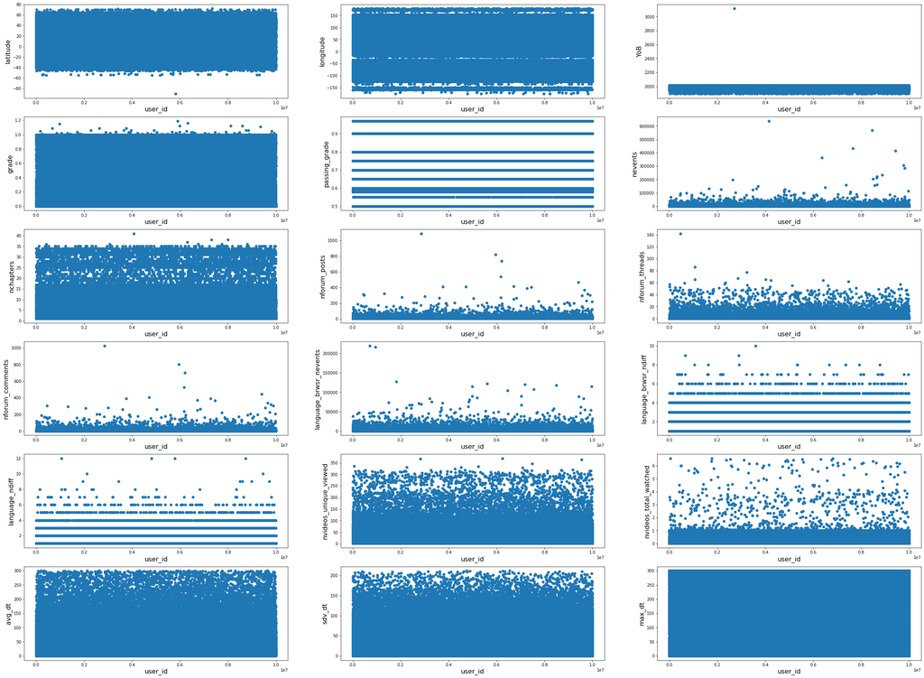

```python
fig, axes = plt.subplots(6, 3, sharey=False, figsize=(40, 30))
for i, ax in enumerate(axes.flat):
    ax.scatter(data["user_id"], data[selected_var[i]])
    ax.set_xlabel("user_id", fontsize=16)
    ax.set_ylabel(selected_var[i], fontsize=16)
```

> 20 - latitude: latitude is found in the dataset but not not found in the student course description file. It is a mismatch between the dataset and the student course description file, which was expected because the description file is for earlier versions of what the edX platform captured about its learners and the information have changed slightly since then. However, if latitude is self-explanatory, and we know the meaning of latitude, we can use it as a quasi-identifier. From the plot above, we can see that the more sparse the scatter plot is, the more powerful the identifier is. Because with more sparse points, we can better categorize and indentify the users. Here, we can see that latitude is not a very powerful quasi-indentifier. It is a continuous variable.

> 21 - longitude: longitude is found in the dataset but not not found in the student course description file. It is a mismatch between the dataset and the student course description file, which was expected because the description file is for earlier versions of what the edX platform captured about its learners and the information have changed slightly since then. However, if longitude is self-explanatory, and we know the meaning of longitude, we can use it as a quasi-identifier. From the plot above, we can see that the more sparse the scatter plot is, the more powerful the identifier is. Because with more sparse points, we can better categorize and indentify the users. Here, we can see that longitude is not a very powerful quasi-indentifier. It is a continuous variable.

> 23 - YoB: Year of birth. This is a quasi-identifiers. Because it has various values and the distributions of YoB across different users are different. It helps us in identification. The variable is a piece of information that does not itself identify an individual, but can do so when combined with other quasi-identifiers. From the plot above, we can see that the more sparse the scatter plot is, the more powerful the identifier is. Because with more sparse points, we can better categorize and indentify the users. Here, we can see that YoB is not a very powerful quasi-indentifier. It is a continuous variable.

> 25 - grade: Final grade earned in the course, on a scale of 0 to 1. This is a quasi-identifiers. Because it has various values and the distributions of grade across different users are different. It helps us in identification. The variable is a piece of information that does not itself identify an individual, but can do so when combined with other quasi-identifiers. From the plot above, we can see that the more sparse the scatter plot is, the more powerful the identifier is. Because with more sparse points, we can better categorize and indentify the users. Here, we can see that grade is not a very powerful quasi-indentifier. It is a continuous variable.

> 26 - passing_grade: Passing grade for this course, on a scale of 0 to 1. This value should be the same within a course. This is a quasi-identifiers. Because it has various values and the distributions of passing_grade across different users are different. It helps us in identification. The variable is a piece of information that does not itself identify an individual, but can do so when combined with other quasi-identifiers. From the plot above, we can see that the more sparse the scatter plot is, the more powerful the identifier is. Because with more sparse points, we can better categorize and indentify the users. Here, we can see that passing_grade is not a powerful quasi-indentifier. It is a continuous variable.

> 30 - nevents: Number of tracking log events. This is a quasi-identifiers. Because it has various values and the distributions of nevents across different users are different. It helps us in identification. The variable is a piece of information that does not itself identify an individual, but can do so when combined with other quasi-identifiers. From the plot above, we can see that the more sparse the scatter plot is, the more powerful the identifier is. Because with more sparse points, we can better categorize and indentify the users. Here, we can see that nevents is a powerful quasi-indentifier. It is a continuous variable.

> 33 - nchapters: Number of chapters visited by the user. This is a quasi-identifiers. Because it has various values and the distributions of nchapters across different users are different. It helps us in identification. The variable is a piece of information that does not itself identify an individual, but can do so when combined with other quasi-identifiers. From the plot above, we can see that the more sparse the scatter plot is, the more powerful the identifier is. Because with more sparse points, we can better categorize and indentify the users. Here, we can see that grade is not a very powerful quasi-indentifier. It is a continuous variable.

> 34 - nforum_posts: Number of forum posts and comments made by user. This represents the sum of forum threads and comments. This is a quasi-identifiers. Because it has various values and the distributions of nforum_posts across different users are different. It helps us in identification. The variable is a piece of information that does not itself identify an individual, but can do so when combined with other quasi-identifiers. From the plot above, we can see that the more sparse the scatter plot is, the more powerful the identifier is. Because with more sparse points, we can better categorize and indentify the users. Here, we can see that nforum_posts is a powerful quasi-indentifier. It is a continuous variable.

> 37 - nforum_threads: Number of forum post threads by user. This is a quasi-identifiers. Because it has various values and the distributions of nforum_threads across different users are different. It helps us in identification. The variable is a piece of information that does not itself identify an individual, but can do so when combined with other quasi-identifiers. From the plot above, we can see that the more sparse the scatter plot is, the more powerful the identifier is. Because with more sparse points, we can better categorize and indentify the users. Here, we can see that nforum_threads is a powerful quasi-indentifier. It is a continuous variable.

> 38 - nforum_comments: Number of forum post comments by user. This is a quasi-identifiers. Because it has various values and the distributions of nforum_comments across different users are different. It helps us in identification. The variable is a piece of information that does not itself identify an individual, but can do so when combined with other quasi-identifiers. From the plot above, we can see that the more sparse the scatter plot is, the more powerful the identifier is. Because with more sparse points, we can better categorize and indentify the users. Here, we can see that nforum_comments is a powerful quasi-indentifier. It is a continuous variable.

> 62 - language_brwsr_nevents: language_brwsr_nevents is found in the dataset but not not found in the student course description file. It is a mismatch between the dataset and the student course description file, which was expected because the description file is for earlier versions of what the edX platform captured about its learners and the information have changed slightly since then. However, if language_brwsr_nevents is self-explanatory, and we know the meaning of language_brwsr_nevents, we can use it as a quasi-identifier. From the plot above, we can see that the more sparse the scatter plot is, the more powerful the identifier is. Because with more sparse points, we can better categorize and indentify the users. Here, we can see that language_brwsr_nevents is a powerful quasi-indentifier. It is a continuous variable.

> 63 - language_brwsr_ndiff: language_brwsr_ndiff is found in the dataset but not not found in the student course description file. It is a mismatch between the dataset and the student course description file, which was expected because the description file is for earlier versions of what the edX platform captured about its learners and the information have changed slightly since then. However, if language_brwsr_ndiff is self-explanatory, and we know the meaning of language_brwsr_ndiff, we can use it as a quasi-identifier. From the plot above, we can see that the more sparse the scatter plot is, the more powerful the identifier is. Because with more sparse points, we can better categorize and indentify the users. Here, we can see that language_brwsr_ndiff is a powerful quasi-indentifier. It is a continuous variable.

> 67 - language_ndiff: count of different transcript languages used per person enrolled in that respective course. This is a quasi-identifiers. Because it has various values and the distributions of language_ndiff across different users are different. It helps us in identification. The variable is a piece of information that does not itself identify an individual, but can do so when combined with other quasi-identifiers. From the plot above, we can see that the more sparse the scatter plot is, the more powerful the identifier is. Because with more sparse points, we can better categorize and indentify the users. Here, we can see that language_ndiff is a powerful quasi-indentifier. It is a continuous variable.

> 71 - nvideos_unique_viewed: Number of unique videos watched. This is a quasi-identifiers. Because it has various values and the distributions of nvideos_unique_viewed across different users are different. It helps us in identification. The variable is a piece of information that does not itself identify an individual, but can do so when combined with other quasi-identifiers. From the plot above, we can see that the more sparse the scatter plot is, the more powerful the identifier is. Because with more sparse points, we can better categorize and indentify the users. Here, we can see that nvideos_unique_viewed is a powerful quasi-indentifier. It is a continuous variable.

> 72 - nvideos_total_watched: Percentage of all videos watched in the course. This is a quasi-identifiers. Because it has various values and the distributions of nvideos_total_watched across different users are different. It helps us in identification. The variable is a piece of information that does not itself identify an individual, but can do so when combined with other quasi-identifiers. From the plot above, we can see that the more sparse the scatter plot is, the more powerful the identifier is. Because with more sparse points, we can better categorize and indentify the users. Here, we can see that nvideos_total_watched is a powerful quasi-indentifier. It is a continuous variable.

> 76 - avg_dt: Average time difference in seconds between consecutive events from tracking logs. This is a quasi-identifiers. Because it has various values and the distributions of avg_dt across different users are different. It helps us in identification. The variable is a piece of information that does not itself identify an individual, but can do so when combined with other quasi-identifiers. From the plot above, we can see that the more sparse the scatter plot is, the more powerful the identifier is. Because with more sparse points, we can better categorize and indentify the users. Here, we can see that avg_dt is not a very powerful quasi-indentifier. It is a continuous variable.

> 77 - sdv_dt: Standard deviation of difference in seconds between consecutive events from tracking logs. This is a quasi-identifiers. Because it has various values and the distributions of sdv_dt across different users are different. It helps us in identification. The variable is a piece of information that does not itself identify an individual, but can do so when combined with other quasi-identifiers. From the plot above, we can see that the more sparse the scatter plot is, the more powerful the identifier is. Because with more sparse points, we can better categorize and indentify the users. Here, we can see that sdv_dt is not a very powerful quasi-indentifier. It is a continuous variable.

> 78 - max_dt: Maximum difference in seconds between consecutive events from tracking logs. This is a quasi-identifiers. Because it has various values and the distributions of max_dt across different users are different. It helps us in identification. The variable is a piece of information that does not itself identify an individual, but can do so when combined with other quasi-identifiers. From the plot above, we can see that the more sparse the scatter plot is, the more powerful the identifier is. Because with more sparse points, we can better categorize and indentify the users. Here, we can see that max_dt is not a very powerful quasi-indentifier. It is a continuous variable.

```python
remain_var = []
for i in range(len(data.columns)):
    if data[data.columns[i]].dtype == np.float64 and data.columns[i] not in float_col_nan and data.columns[i] not in selected_var:
        remain_var.append(data.columns[i])
with pd.option_context('display.max_rows', None, 'display.max_columns', None):  # more options can be specified also
    print(data.describe()[remain_var])
```

```
           ndays_act    nplay_video  nforum_votes  nforum_endorsed  \
count  874420.000000  874250.000000  39360.000000     39360.000000
mean        6.768124      41.016666      1.967353         0.029573
std        21.330110     393.593691     19.149008         0.829344
min         1.000000       0.000000      0.000000         0.000000
25%         1.000000       0.000000      0.000000         0.000000
50%         2.000000       0.000000      0.000000         0.000000
75%         5.000000      10.000000      1.000000         0.000000
max      2648.000000  114562.000000   2507.000000        78.000000

       nforum_pinned     nprogcheck  nproblem_check  nforum_events  \
count   39360.000000  874250.000000   874250.000000  874250.000000
mean        0.008003       0.704307       21.844113       3.075430
std         0.501794       6.060285      166.463664      58.705821
min         0.000000       0.000000        0.000000       0.000000
25%         0.000000       0.000000        0.000000       0.000000
50%         0.000000       0.000000        0.000000       0.000000
75%         0.000000       0.000000        0.000000       0.000000
max        77.000000     643.000000    26367.000000   17829.000000

          is_active  y1_anomalous  language_download  language_nevents  \
count  1.136664e+06        5094.0      407409.000000      4.074090e+05
mean   8.449533e-01           1.0           0.103596      5.889448e+01
std    3.619494e-01           0.0           1.335100      2.586551e+03
min    0.000000e+00           1.0           0.000000      1.000000e+00
25%    1.000000e+00           1.0           0.000000      3.000000e+00
50%    1.000000e+00           1.0           0.000000      9.000000e+00
75%    1.000000e+00           1.0           0.000000      3.400000e+01
max    1.000000e+00           1.0         273.000000      1.041151e+06

         ntranscript   nshow_answer         nvideo      nseq_goto  \
count  874250.000000  874250.000000  874250.000000  874250.000000
mean        3.746311       2.128075      41.016666      11.434813
std        56.395547      26.677850     393.593691      77.247660
min         0.000000       0.000000       0.000000       0.000000
25%         0.000000       0.000000       0.000000       0.000000
50%         0.000000       0.000000       0.000000       0.000000
75%         0.000000       0.000000      10.000000       1.000000
max     25500.000000    6554.000000  114562.000000   12002.000000

```

[output cut: 24 more lines]

```
min              1.0                 1.0                     1.0
25%              1.0                 1.0                     1.0
50%              1.0                 1.0                     1.0
75%              1.0                 1.0                     1.0
max              1.0                 1.0                     1.0

       forumRoles_isStudent
count             1141689.0
mean                    1.0
std                     0.0
min                     1.0
25%                     1.0
50%                     1.0
75%                     1.0
max                     1.0
```

```python
print(remain_var)
```

[output not shown]

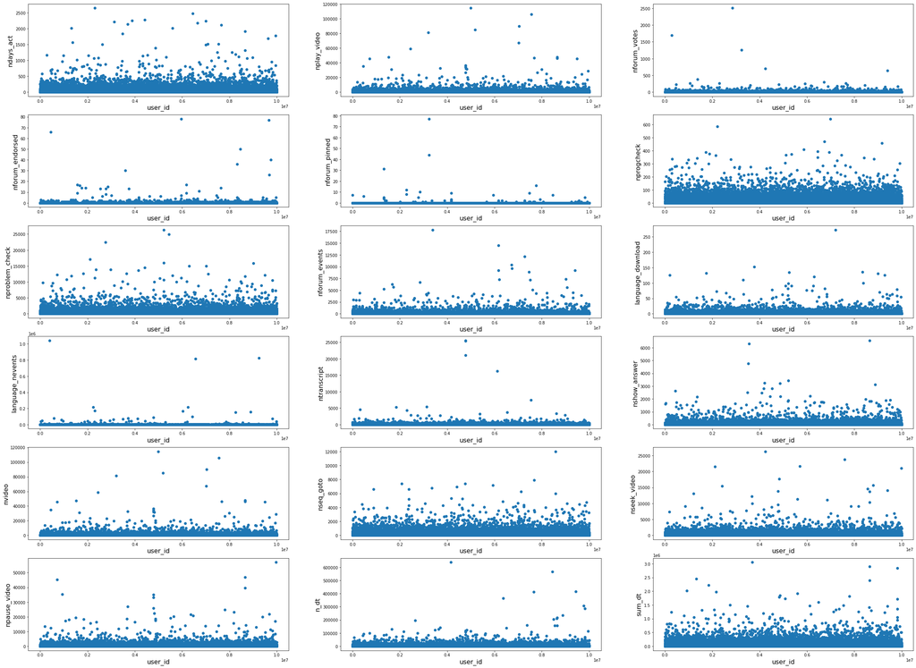

```python
continuous_remain = ['ndays_act', 'nplay_video', 'nforum_votes', 'nforum_endorsed', 'nforum_pinned',
                     'nprogcheck', 'nproblem_check', 'nforum_events', 'language_download', 'language_nevents',
                     'ntranscript', 'nshow_answer', 'nvideo', 'nseq_goto', 'nseek_video',
                     'npause_video', 'n_dt', 'sum_dt']
fig, axes = plt.subplots(6, 3, sharey=False, figsize=(40, 30))
for i, ax in enumerate(axes.flat):
    ax.scatter(data["user_id"], data[continuous_remain[i]])
    ax.set_xlabel("user_id", fontsize=16)
    ax.set_ylabel(continuous_remain[i], fontsize=16)
```

> 31 - ndays_act: This is a quasi-identifiers. Because it has various values and the distributions of ndays_act across different users are different. It helps us in identification. The variable is a piece of information that does not itself identify an individual, but can do so when combined with other quasi-identifiers. From the plot above, we can see that the more sparse the scatter plot is, the more powerful the identifier is. Because with more sparse points, we can better categorize and indentify the users. Here, we can see that ndays_act is a powerful quasi-indentifier. It is a continuous variable.

> 32 - nplay_video: Number of video play events from tracking logs. Because it has various values and the distributions of nplay_video across different users are different. It helps us in identification. The variable is a piece of information that does not itself identify an individual, but can do so when combined with other quasi-identifiers. From the plot above, we can see that the more sparse the scatter plot is, the more powerful the identifier is. Because with more sparse points, we can better categorize and indentify the users. Here, we can see that nplay_video is a powerful quasi-indentifier. It is a continuous variable.

> 35 - nforum_votes: Number of votes received by user's forum posts. Because it has various values and the distributions of nforum_votes across different users are different. It helps us in identification. The variable is a piece of information that does not itself identify an individual, but can do so when combined with other quasi-identifiers. From the plot above, we can see that the more sparse the scatter plot is, the more powerful the identifier is. Because with more sparse points, we can better categorize and indentify the users. Here, we can see that nforum_votes is a powerful quasi-indentifier. It is a continuous variable.

> 36 - nforum_endorsed: Number of endorsed forum posts by user. Because it has various values and the distributions of nforum_endorsed across different users are different. It helps us in identification. The variable is a piece of information that does not itself identify an individual, but can do so when combined with other quasi-identifiers. From the plot above, we can see that the more sparse the scatter plot is, the more powerful the identifier is. Because with more sparse points, we can better categorize and indentify the users. Here, we can see that nforum_endorsed is a powerful quasi-indentifier. It is a continuous variable.

> 39 - nforum_pinned: Number of forum posts by user which were pinned (good indicator of staff). Because it has various values and the distributions of nforum_pinned across different users are different. It helps us in identification. The variable is a piece of information that does not itself identify an individual, but can do so when combined with other quasi-identifiers. From the plot above, we can see that the more sparse the scatter plot is, the more powerful the identifier is. Because with more sparse points, we can better categorize and indentify the users. Here, we can see that nforum_pinned is a powerful quasi-indentifier. It is a continuous variable.

> 41 - nprogcheck: Number of progress check events from tracking logs. Because it has various values and the distributions of nprogcheck across different users are different. It helps us in identification. The variable is a piece of information that does not itself identify an individual, but can do so when combined with other quasi-identifiers. From the plot above, we can see that the more sparse the scatter plot is, the more powerful the identifier is. Because with more sparse points, we can better categorize and indentify the users. Here, we can see that nprogcheck is a powerful quasi-indentifier. It is a continuous variable.

> 42 - nproblem_check: Number of problem check events from tracking logs. Because it has various values and the distributions of nproblem_check across different users are different. It helps us in identification. The variable is a piece of information that does not itself identify an individual, but can do so when combined with other quasi-identifiers. From the plot above, we can see that the more sparse the scatter plot is, the more powerful the identifier is. Because with more sparse points, we can better categorize and indentify the users. Here, we can see that nproblem_check is a powerful quasi-indentifier. It is a continuous variable.

> 43 - nforum_events: Number of all kinds of forum events, from tracking logs. Because it has various values and the distributions of nforum_events across different users are different. It helps us in identification. The variable is a piece of information that does not itself identify an individual, but can do so when combined with other quasi-identifiers. From the plot above, we can see that the more sparse the scatter plot is, the more powerful the identifier is. Because with more sparse points, we can better categorize and indentify the users. Here, we can see that nforum_events is a powerful quasi-indentifier. It is a continuous variable.

> 45 - is_active: 1 if enrollment active on date of this data, else 0. This is a quasi-identifiers. Because it has the values of both 1 and 0. It helps us in identification. The variable is a piece of information that does not itself identify an individual, but can do so when combined with other quasi-identifiers. It is a categorical variable.

> 52 - y1_anomalous: if this user was anomalously missing and had to be side-loaded from mongo then this field = 1, else null. Because it has the values of both 1 and null. And null has meaning instead of representing missing data. It helps us in identification. The variable is a piece of information that does not itself identify an individual, but can do so when combined with other quasi-identifiers. It is a categorical variable.

> 65 - language_download: modal transcript language download count for any video. Because it has various values and the distributions of language_download across different users are different. It helps us in identification. The variable is a piece of information that does not itself identify an individual, but can do so when combined with other quasi-identifiers. From the plot above, we can see that the more sparse the scatter plot is, the more powerful the identifier is. Because with more sparse points, we can better categorize and indentify the users. Here, we can see that language_download is a powerful quasi-indentifier. It is a continuous variable.

> 66 - language_nevents: modal transcript language events. Because it has various values and the distributions of language_nevents across different users are different. It helps us in identification. The variable is a piece of information that does not itself identify an individual, but can do so when combined with other quasi-identifiers. From the plot above, we can see that the more sparse the scatter plot is, the more powerful the identifier is. Because with more sparse points, we can better categorize and indentify the users. Here, we can see that language_nevents is a powerful quasi-indentifier. It is a continuous variable.

> 68 - ntranscript: Number of video show transcript events from tracking logs. Because it has various values and the distributions of ntranscript across different users are different. It helps us in identification. The variable is a piece of information that does not itself identify an individual, but can do so when combined with other quasi-identifiers. From the plot above, we can see that the more sparse the scatter plot is, the more powerful the identifier is. Because with more sparse points, we can better categorize and indentify the users. Here, we can see that ntranscript is a powerful quasi-indentifier. It is a continuous variable.

> 69 - nshow_answer: Number of show answer events from tracking logs. Because it has various values and the distributions of nshow_answer across different users are different. It helps us in identification. The variable is a piece of information that does not itself identify an individual, but can do so when combined with other quasi-identifiers. From the plot above, we can see that the more sparse the scatter plot is, the more powerful the identifier is. Because with more sparse points, we can better categorize and indentify the users. Here, we can see that nshow_answer is a powerful quasi-indentifier. It is a continuous variable.

> 70 - nvideo: Number of video events (of all kinds) from tracking logs. Because it has various values and the distributions of nvideo across different users are different. It helps us in identification. The variable is a piece of information that does not itself identify an individual, but can do so when combined with other quasi-identifiers. From the plot above, we can see that the more sparse the scatter plot is, the more powerful the identifier is. Because with more sparse points, we can better categorize and indentify the users. Here, we can see that nvideo is a powerful quasi-indentifier. It is a continuous variable.

> 73 - nseq_goto: Number of 'sequence goto' navigational events from tracking logs. Because it has various values and the distributions of nseq_goto across different users are different. It helps us in identification. The variable is a piece of information that does not itself identify an individual, but can do so when combined with other quasi-identifiers. From the plot above, we can see that the more sparse the scatter plot is, the more powerful the identifier is. Because with more sparse points, we can better categorize and indentify the users. Here, we can see that nseq_goto is a powerful quasi-indentifier. It is a continuous variable.

> 74 - nseek_video: Number of 'video seek' events from tracking logs. Because it has various values and the distributions of nseek_video across different users are different. It helps us in identification. The variable is a piece of information that does not itself identify an individual, but can do so when combined with other quasi-identifiers. From the plot above, we can see that the more sparse the scatter plot is, the more powerful the identifier is. Because with more sparse points, we can better categorize and indentify the users. Here, we can see that nseek_video is a powerful quasi-indentifier. It is a continuous variable.

> 75 - npause_video: Number of 'video pause' events from tracking logs. Because it has various values and the distributions of npause_video across different users are different. It helps us in identification. The variable is a piece of information that does not itself identify an individual, but can do so when combined with other quasi-identifiers. From the plot above, we can see that the more sparse the scatter plot is, the more powerful the identifier is. Because with more sparse points, we can better categorize and indentify the users. Here, we can see that npause_video is a powerful quasi-indentifier. It is a continuous variable.

> 79 - n_dt: Number of consecutive events used in time difference computations, from tracking logs. Because it has various values and the distributions of n_dt across different users are different. It helps us in identification. The variable is a piece of information that does not itself identify an individual, but can do so when combined with other quasi-identifiers. From the plot above, we can see that the more sparse the scatter plot is, the more powerful the identifier is. Because with more sparse points, we can better categorize and indentify the users. Here, we can see that n_dt is a powerful quasi-indentifier. It is a continuous variable.

> 80 - sum_dt: Total elapsed time (in seconds) spent by user on this course, based on time difference of consecutive events, with 5 min max cutoff, from tracking logs. Because it has various values and the distributions of sum_dt across different users are different. It helps us in identification. The variable is a piece of information that does not itself identify an individual, but can do so when combined with other quasi-identifiers. From the plot above, we can see that the more sparse the scatter plot is, the more powerful the identifier is. Because with more sparse points, we can better categorize and indentify the users. Here, we can see that sum_dt is a powerful quasi-indentifier. It is a continuous variable.

> 81 - roles_isBetaTester: if user is a course beta tester with ‘role’ = ‘beta_tester’ from edX table: student_courseaccessrole; otherwise NULL. This is a quasi-identifiers. Because it has the values of both 1 and NULL. And NULL has meaning instead of representing missing data. It helps us in identification. The variable is a piece of information that does not itself identify an individual, but can do so when combined with other quasi-identifiers. It is a categorical variable.

> 82 - roles_isInstructor: 1 if user is a course instructor with ‘role’ = ‘instructor’ from edX table: student_courseaccessrole; otherwise NULL. This is a quasi-identifiers. Because it has the values of both 1 and NULL. And NULL has meaning instead of representing missing data. It helps us in identification. The variable is a piece of information that does not itself identify an individual, but can do so when combined with other quasi-identifiers. It is a categorical variable.

> 83 - roles_isStaff: 1 if user is course staff (or other staff roles) with ‘role’ = ‘staff’ from edX table: student_courseaccessrole; otherwise NULL. This is a quasi-identifiers. Because it has the values of both 1 and NULL. And NULL has meaning instead of representing missing data. It helps us in identification. The variable is a piece of information that does not itself identify an individual, but can do so when combined with other quasi-identifiers. It is a categorical variable.

> 85 - roles_isFinance: 1 if user is finance admin with ‘role’ = ‘finance_admin’ from edX table:student_courseaccessrole; otherwise NULL. This is a quasi-identifiers. Because it has the values of both 1 and NULL. And NULL has meaning instead of representing missing data. It helps us in identification. The variable is a piece of information that does not itself identify an individual, but can do so when combined with other quasi-identifiers. It is a categorical variable.

> 87 - roles_isSales: 1 if user is sales admin with ‘role’ = ‘sales_admin’ from edX Table: student_courseaccessrole; otherwise NULL. This is a quasi-identifiers. Because it has the values of both 1 and NULL. And NULL has meaning instead of representing missing data. It helps us in identification. The variable is a piece of information that does not itself identify an individual, but can do so when combined with other quasi-identifiers. It is a categorical variable.

> 88 - forumRoles_isAdmin: 1 if user is a forum admin with ‘name’ = ‘Administrator’ from edX table: django_comment_client_role_users; otherwise NULL. Because it has the values of both 1 and NULL. And NULL has meaning instead of representing missing data. It helps us in identification. The variable is a piece of information that does not itself identify an individual, but can do so when combined with other quasi-identifiers. It is a categorical variable.

> 90 - forumRoles_isModerator: 1 if user is a forum moderator with ‘name’ = ‘Moderator'. Because it has the values of both 1 and NULL. And NULL has meaning instead of representing missing data. It helps us in identification. The variable is a piece of information that does not itself identify an individual, but can do so when combined with other quasi-identifiers. It is a categorical variable.

> 91 - forumRoles_isStudent: 1 if user is a forum student (everyone in the course seems to be assigned this) with ‘name’ = ‘Student’, otherwise NULL. Because it has the values of both 1 and NULL. And NULL has meaning instead of representing missing data. It helps us in identification. The variable is a piece of information that does not itself identify an individual, but can do so when combined with other quasi-identifiers. It is a categorical variable.

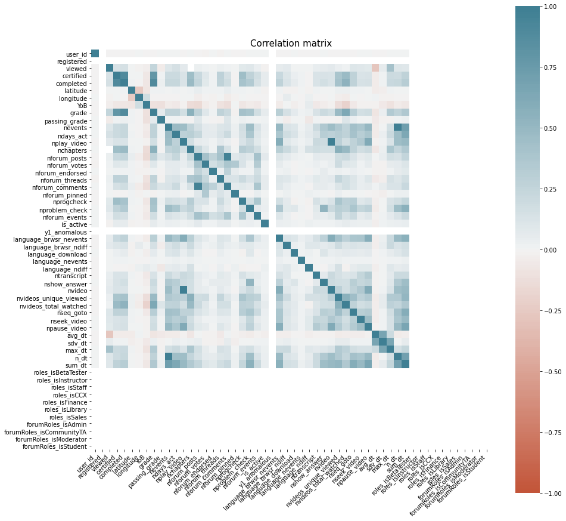

```python
fig, ax = plt.subplots(figsize=(15, 15))
corr = data[[i for i in data.columns]].corr()
ax = sns.heatmap(
    corr,
    vmin=-1, vmax=1, center=0,
    cmap=sns.diverging_palette(20, 220, n=200),
    square=True
)
ax.set_xticklabels(
    ax.get_xticklabels(),
    rotation=45,
    horizontalalignment='right'
);
ax.set_title('Correlation matrix',fontsize=15)
```

## Summary

> Quasi-identifiers are pieces of information that are not of themselves unique identifiers, but are sufficiently well correlated with an entity that they can be combined with other quasi-identifiers to uniquely identify an individual. Based on our analysis above, we conclude that the direct identifiers are ‘user_id’ and ‘verified_enroll_time’.

> Categorical quasi-identifiers include ‘username’, ‘explored’, ‘ip’, ‘cc_by_ip’, ‘countryLabel’, ‘city’, ‘region’, ‘subdivision’, ‘postalCode’, ‘un_major_region’, ‘un_economic_group’,, ‘un_special_region’, ‘LoE’, ‘gender’, ‘start_time’, ‘first_event’, ‘last_event’, ‘roles’, ‘mode’, ‘cert_created_date’, ‘cert_modified_date’, ‘cert_status’, ‘profile_country’, ‘email_domain’, ‘language_brwsr’, ‘language_brwsr_country’, ‘viewed’, ‘certified’, ‘completed’, language_brwsr_sec_country’, ‘language_brwsr_code’, ‘language_brwsr_subcode’, ‘language_brwsr_sec_code’, ‘language_brwsr_sec_subcode’, ‘language’, ‘is_active’, ‘y1_anomalous’, ‘roles_isBetaTester’, ‘roles_isInstructor’, ‘roles_isStaff’, ‘roles_isFinance’, ‘roles_isSales’, ‘forumRoles_isModerator’, and ‘forumRoles_isStudent’.

> Continuous quasi-identifiers identifiers include 'latitude', 'longitude', 'YoB', 'grade', 'passing_grade', 'nevents', 'nchapters', 'nforum_posts', 'nforum_threads', 'nforum_comments', 'language_brwsr_nevents', 'language_brwsr_ndiff', 'language_ndiff', 'nvideos_unique_viewed', 'nvideos_total_watched', 'avg_dt', 'sdv_dt', 'max_dt', ‘ndays_act’, ‘nplay_video’, ‘nforum_votes’, ‘nforum_endorsed’, ‘nforum_pinned’, ‘nprogcheck’, ‘nproblem_check’, ‘nforum_events’, ‘language_download’, ‘language_nevents’, ‘ntranscript’, ‘nshow_answer’, ‘nvideo’, ‘nseq_goto’, ‘nseek_video’, ‘npause_video’, ‘n_dt’, and ‘sum_dt’.

> Unsure variables given the provided information: ‘verified_unenroll_time’ and ‘un_developing_nation’.